# HW 4

Descriptive Statistics and Visualization

Alexis Gamez  
4/10/2022

# Setup

```r
library(tidyverse)
```

# Data Set

For this assignment I used a data set originally provided by the CDC as a part of the Behavioral Risk Factor Surveillance System (BRFSS), which is a system that conducts telephone surveys to gather data on the health statuses of US residents

```r
heart<-read_csv("C:/Users/Leshiii/Desktop/DACSS Master's/DACSS 601/HW4/heart_2020_cleaned.csv")
# Rows: 319795 Columns: 18

#Confirming that the data set was read in correctly
head(heart)
```

```
# A tibble: 6 x 18
  HeartDisease   BMI Smoking AlcoholDrinking Stroke PhysicalHealth
  <chr>        <dbl> <chr>   <chr>           <chr>           <dbl>
1 No            16.6 Yes     No              No                  3
2 No            20.3 No      No              Yes                 0
3 No            26.6 Yes     No              No                 20
4 No            24.2 No      No              No                  0
5 No            23.7 No      No              No                 28
6 Yes           28.9 Yes     No              No                  6
# ... with 12 more variables: MentalHealth <dbl>, DiffWalking <chr>,
#   Sex <chr>, AgeCategory <chr>, Race <chr>, Diabetic <chr>,
#   PhysicalActivity <chr>, GenHealth <chr>, SleepTime <dbl>,
#   Asthma <chr>, KidneyDisease <chr>, SkinCancer <chr>
```

## Data Set Variables

1. **Heart Disease**: Character Data *(Yes/No)*
2. **BMI**: Numeric/Doubles Data *(16.6/20.3/etc)*
3. **Smoking**: Character Data *(Yes/No)*
4. **Alcohol Drinking**: Character Data *(Yes/No)*
5. **Stroke**: Character Data *(Yes/No)*
6. **Physical Health**: Numeric Data *(1/2/3/etc.)*
7. **Mental Health**: Numeric Data *(1/2/3/etc.)*
8. **Diff Walking**: Character Data *(Yes/No)*
9. **Sex**: Character Data *(Female/Male)*
10. **Age Category**: Character Data *(55-59/65-69/etc.)*
11. **Race**: Character Data *(White/Black/etc.)*
12. **Diabetic**: Character Data *(Yes/No)*
13. **Physical Activity**: Character Data *(Yes/No)*
14. **Gen Health**: Character Data *(Good/Fair/Poor/etc.)*
15. **Sleep Time**: Numeric Data *(1/2/3/etc.)*
16. **Asthma**: Character Data *(Yes/No)*
17. **Kidney Disease**: Character Data *(Yes/No)*
18. **Skin Cancer**: Character Data *(Yes/No)*

# **Part 1**

## *Computing Descriptive Statistics for Numeric & Categorical Data*

### Numeric Data

```r
# Calculating the mean, median & standard deviation of the Mental Health variable
# z_variable include all zero values within the data frame, while nz_variable filters out all zero values
z_mental <- heart %>%
   summarize(Mental_Mean = mean(MentalHealth),
          Mental_Median = median(MentalHealth),
          Mental_SD = sd(MentalHealth))
z_mental
```

```
# A tibble: 1 x 3
  Mental_Mean Mental_Median Mental_SD
        <dbl>         <dbl>     <dbl>
1        3.90             0      7.96
```

```r
nz_mental <- heart %>%
   filter(MentalHealth > 0) %>%
   summarize(Mental_Mean = mean(MentalHealth),
              Mental_Median = median(MentalHealth),
              Mental_SD = sd(MentalHealth))
nz_mental
```

```
# A tibble: 1 x 3
  Mental_Mean Mental_Median Mental_SD
        <dbl>         <dbl>     <dbl>
1        10.9             6      10.0
```

```r
# Calculating the mean, median & standard deviation of the Physical Health variable
z_phys <- heart %>%
   summarize(Phys_Mean = mean(PhysicalHealth),
             Phys_Median = median(PhysicalHealth),
             Phys_SD = sd(PhysicalHealth))
z_phys
```

```
# A tibble: 1 x 3
  Phys_Mean Phys_Median Phys_SD
      <dbl>       <dbl>   <dbl>
1      3.37           0    7.95
```

```r
nz_phys <- heart %>%
   filter(PhysicalHealth > 0) %>%
   summarize(Phys_Mean = mean(PhysicalHealth),
             Phys_Median = median(PhysicalHealth),
             Phys_SD = sd(PhysicalHealth))
nz_phys
```

```
# A tibble: 1 x 3
  Phys_Mean Phys_Median Phys_SD
      <dbl>       <dbl>   <dbl>
1      11.6           6    11.0
```

```r
# Calculating the mean, median & standard deviation of the Sleep Time variable
z_sleep <- heart %>%
   summarize(Sleep_Mean = mean(SleepTime),
             Sleep_Median = median(SleepTime),
             Sleep_SD = sd(SleepTime))
z_sleep
```

```
# A tibble: 1 x 3
  Sleep_Mean Sleep_Median Sleep_SD
       <dbl>        <dbl>    <dbl>
1       7.10            7     1.44
```

```r
# Unnecessary considering all values are above 0, included for consistency
nz_sleep <- heart %>%
   filter(SleepTime > 0) %>%
   summarize(Sleep_Mean = mean(SleepTime),
             Sleep_Median = median(SleepTime),
             Sleep_SD = sd(SleepTime))
```

### Categorical Data

```r
# Calculating the proportion of all participants and participants reporting heart disease according to their race.
race <- select(heart, Race)
p_race <- prop.table(table(race))*100
p_race
```

```
race
American Indian/Alaskan Native                          Asian
                      1.626667                       2.522866
                         Black                       Hispanic
                      7.173033                       8.582373
                         Other                          White
                      3.417189                      76.677872
```

```r
race_heart <- heart %>%
   filter(`HeartDisease` == "Yes") %>%
   select(Race)
prop.table(table(race_heart))*100
```

```
race_heart
American Indian/Alaskan Native                          Asian
                     1.9800533                      0.9717605
                         Black                       Hispanic
                     6.3164432                      5.2716180
                         Other                          White
                     3.2367662                     82.2233588
```

```r
# Because the proportion of white participants is so high, it may skew/overcast the results according to lesser reported races. As a remedy, I created a separate data set excluding white participants.
nw_race_heart <- heart %>%
   filter(`HeartDisease` == "Yes", `Race` != "White") %>%
   select(Race)
prop.table(table(nw_race_heart))*100
```

```
nw_race_heart
American Indian/Alaskan Native                          Asian
                     11.138512                       5.466502
                         Black                       Hispanic
                     35.532265                      29.654747
                         Other
                     18.207974
```

```r
# Calculating the proportion of all participants and participants reporting heart disease according to their age group.
age <- select(heart, AgeCategory)
p_age <- prop.table(table(age))*100
p_age
```

```
age
      18-24       25-29       30-34       35-39       40-44
   6.586720    5.301834    5.864069    6.425992    6.568583
      45-49       50-54       55-59       60-64       65-69
   6.814053    7.936960    9.305024   10.533623   10.679029
      70-74       75-79 80 or older
   9.714036    6.717428    7.552651
```

```r
age_heart <- heart %>%
   filter(`HeartDisease` == "Yes") %>%
   select(AgeCategory)
prop.table(table(age_heart))*100
```

```
age_heart
      18-24       25-29       30-34       35-39       40-44
  0.4749205   0.4858802   0.8256311   1.0813575   1.7754722
      45-49       50-54       55-59       60-64       65-69
  2.7180068   5.0524239   8.0444233  12.1543126  14.9819165
      70-74       75-79 80 or older
 17.7072298  14.7919483  19.9064772
```

```r
# Calculating the proportion of all participants and participants reporting heart disease according to their reported General Health in the last 30 days.
gen <- select(heart, GenHealth)
p_gen <- prop.table(table(gen))*100
p_gen
```

```
gen
Excellent      Fair      Good      Poor Very good
20.901515 10.843509 29.121468  3.530074 35.603433
```

```r
gen_heart <- heart %>%
   filter(`HeartDisease` == "Yes") %>%
   select(GenHealth)
prop.table(table(gen_heart))*100
```

```
gen_heart
Excellent      Fair      Good      Poor Very good
 5.479852 25.879516 34.917620 14.064955 19.658057
```

```r
# Calculating the proportion of all participants and participants reporting heart disease according to their reported physical activity.
physical <- select(heart, PhysicalActivity)
p_physical <- prop.table(table(physical))*100
p_physical
```

```
physical
      No      Yes
22.46377 77.53623
```

```r
phys_heart <- heart %>%
   filter(`HeartDisease` == "Yes") %>%
   select(PhysicalActivity)
prop.table(table(phys_heart))*100
```

```
phys_heart
      No      Yes
36.10857 63.89143
```

```r
# Calculating the proportion of all participants and participants reporting heart disease according to whether or not they smoke.
smoke <- select(heart, Smoking)
p_smoke <- prop.table(table(smoke))*100
p_smoke
```

```
smoke
      No      Yes
58.75233 41.24767
```

```r
smoke_heart <- heart %>%
   filter(`HeartDisease` == "Yes") %>%
   select(Smoking)
prop.table(table(smoke_heart))*100
```

```
smoke_heart
      No      Yes
41.41307 58.58693
```

```r
# Calculating the proportion of all participants and participants reporting heart disease according to whether or not they drink alcohol regularly.
alcohol <- select(heart, AlcoholDrinking)
p_alcohol <- prop.table(table(alcohol))
p_alcohol
```

```
alcohol
        No        Yes
0.93190325 0.06809675
```

```r
alc_heart <- heart %>%
   filter(`HeartDisease` == "Yes") %>%
   select(AlcoholDrinking)
prop.table(table(alc_heart))*100
```

```
alc_heart
       No       Yes
95.831659  4.168341
```

```r
# Calculating the proportion of all participants and participants reporting heart disease according to whether or not they have had a stroke.
stroke <- select(heart, Stroke)
p_stroke <- prop.table(table(stroke))*100
p_stroke
```

```
stroke
      No      Yes
96.22602  3.77398
```

```r
stroke_heart <- heart %>%
   filter(`HeartDisease` == "Yes") %>%
   select(Stroke)
prop.table(table(stroke_heart))*100
```

```
stroke_heart
      No      Yes
83.96595 16.03405
```

```r
# Calculating the proportion of all participants and participants reporting heart disease according to whether or not they have diabetes.
diabetes <- select(heart, Diabetic)
p_diabetes <- prop.table(table(diabetes))*100
p_diabetes
```

```
diabetes
                     No No, borderline diabetes
             84.3205804               2.1204209
                    Yes  Yes (during pregnancy)
             12.7587986               0.8002001
```

```r
diab_heart <- heart %>%
   filter(`HeartDisease` == "Yes") %>%
   select(Diabetic)
prop.table(table(diab_heart))*100
```

```
diab_heart
                     No No, borderline diabetes
             64.0010229               2.8824024
                    Yes  Yes (during pregnancy)
             32.7220254               0.3945494
```

# **Part 2**

## *Creating Uni-variate & Bi-variate Visualizations of the Data Set*

### Uni-variate Visualizations

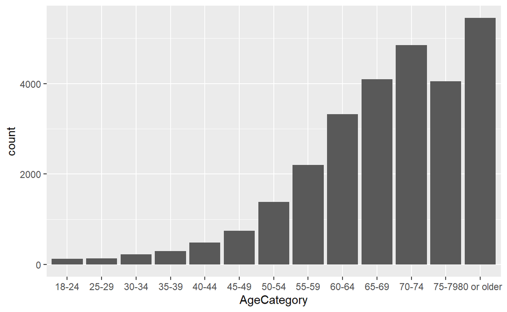

```r
# The first thing I wanted to visualize was whether heart disease was more prominent in certain age groups than others. This was confirmed as the bar graph below displays that heart disease is much more common in participants ages 55 and up.
ggplot(age_heart, aes(AgeCategory)) + geom_bar()
```

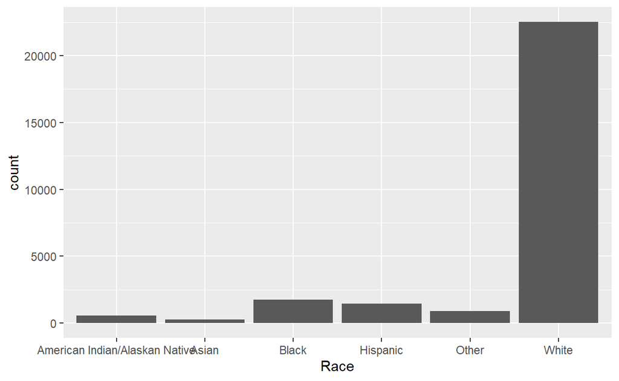

```r
#Similarly, I wanted to create a visual that depicted the frequency of heart disease within certain races of people. Like mentioned above, the overwhelming quantity of participants who were white obscures the results of those participants that are not. As a result, I've also included a function that prioritizes the visualization of non-white participant data.
ggplot(race_heart, aes(Race)) + geom_bar()
```

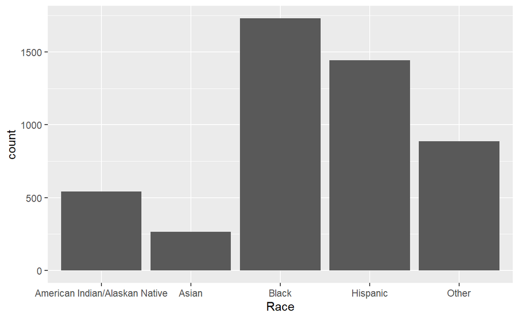

```r
ggplot(nw_race_heart, aes(Race)) + geom_bar()
```

### Bi-variate Visualizations

```r
# Creating data sets that include all previously analyzed variables considering only those that reported having heart disease.
w_heart <- heart %>%
   filter(`HeartDisease` == "Yes") %>%
   select(Race,
          AgeCategory,
          PhysicalActivity,
          Smoking,
          AlcoholDrinking,
          Stroke,
          Diabetic,
          MentalHealth,
          PhysicalHealth,
          SleepTime,
          GenHealth)

nw_w_heart <- heart %>%
   filter(`HeartDisease` == "Yes", `Race` != "White") %>%
   select(Race,
          AgeCategory,
          PhysicalActivity,
          Smoking,
          AlcoholDrinking,
          Stroke,
          Diabetic,
          MentalHealth,
          PhysicalHealth,
          SleepTime,
          GenHealth)
```

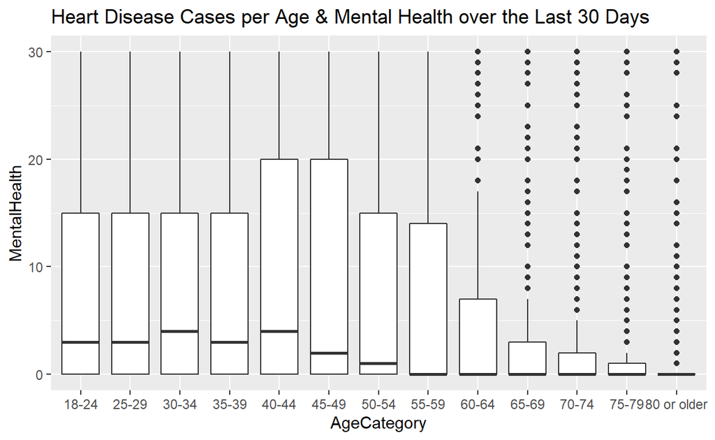

```r
# Gauging correlation between mental health, physical health and heart disease according to age.
ggplot(w_heart, aes(AgeCategory, MentalHealth)) +
  geom_boxplot() +
  labs(title = "Heart Disease Cases per Age & Mental Health over the Last 30 Days")
```

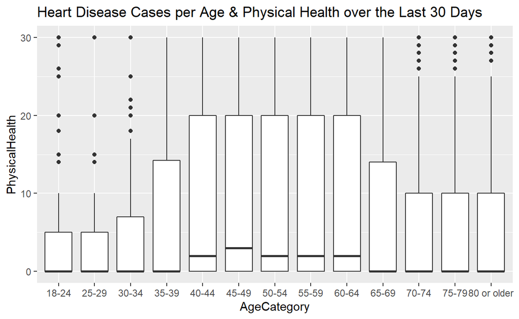

```r
ggplot(w_heart, aes(AgeCategory, PhysicalHealth)) +
  geom_boxplot() +
  labs(title = "Heart Disease Cases per Age & Physical Health over the Last 30 Days")
```

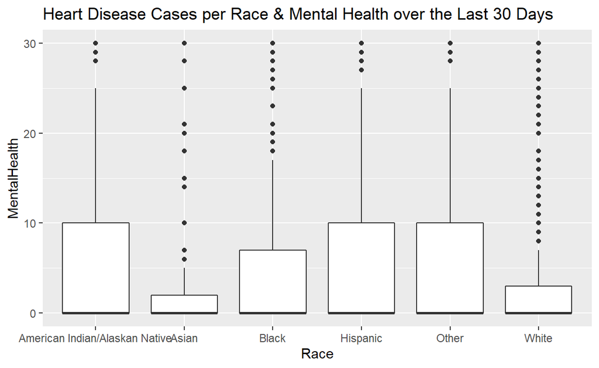

```r
# Gauging correlation between mental health, physical health and heart disease according to race.
ggplot(w_heart, aes(Race, MentalHealth)) +
  geom_boxplot() +
  labs(title = "Heart Disease Cases per Race & Mental Health over the Last 30 Days")
```

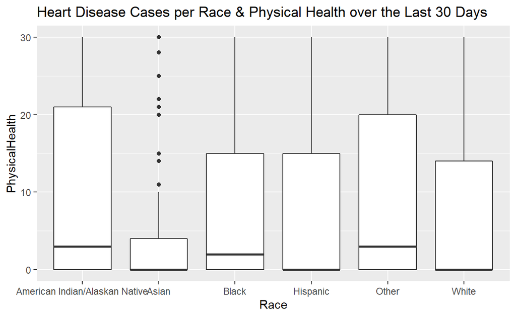

```r
ggplot(w_heart, aes(Race, PhysicalHealth)) +
  geom_boxplot() +
  labs(title = "Heart Disease Cases per Race & Physical Health over the Last 30 Days")
```

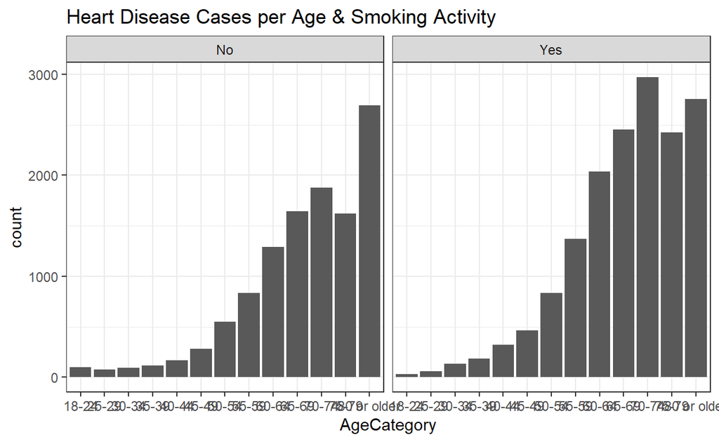

```r
# Analyzing correlation between smoking activity & heart disease according to age & race.
ggplot(w_heart, aes(AgeCategory)) +
  geom_histogram(stat = "count") +
  labs(title = "Heart Disease Cases per Age & Smoking Activity") +
  theme_bw() +
  facet_wrap(vars(Smoking))
```

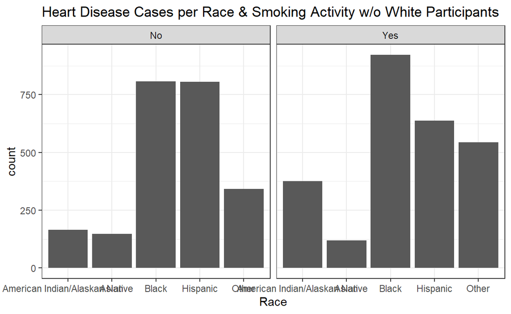

```r
ggplot(nw_w_heart, aes(Race)) +
  geom_histogram(stat = "count") +
  labs(title = "Heart Disease Cases per Race & Smoking Activity w/o White Participants") +
  theme_bw() +
  facet_wrap(vars(Smoking))
```

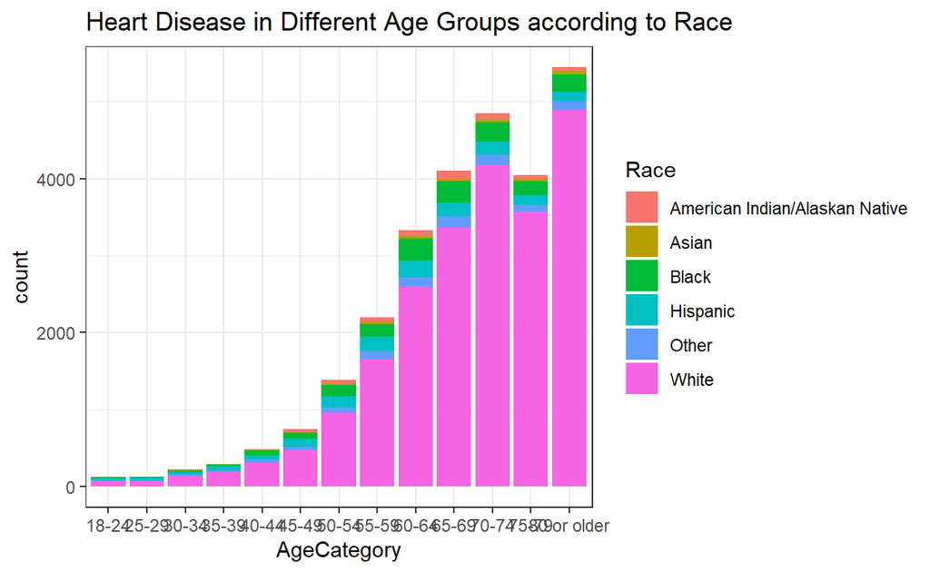

```r
# Analyzing the prevalence of heart disease in different racial groups according to age.
ggplot(w_heart, aes(AgeCategory, fill = Race)) +
  geom_histogram(stat = "count") +
  labs(title = "Heart Disease in Different Age Groups according to Race") +
  theme_bw()
```

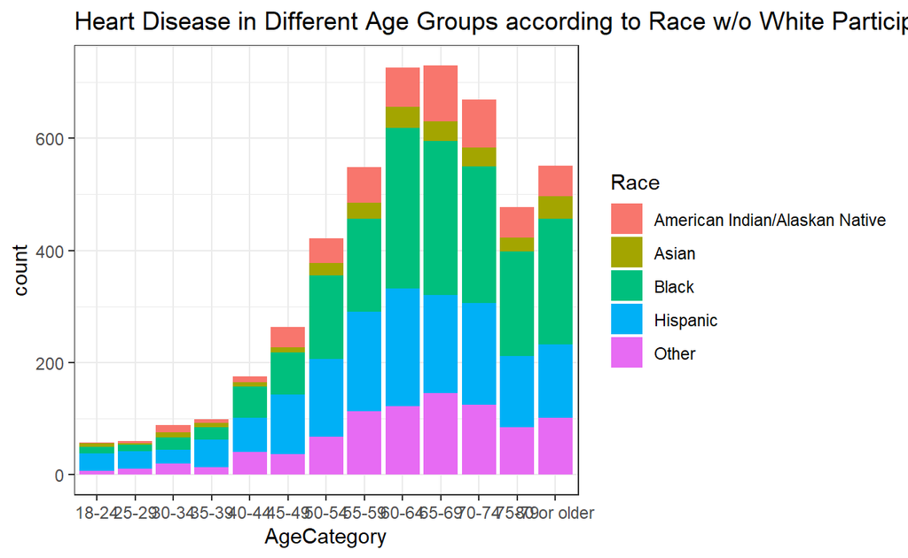

```r
ggplot(nw_w_heart, aes(AgeCategory, fill = Race)) +
  geom_histogram(stat = "count") +
  labs(title = "Heart Disease in Different Age Groups according to Race w/o White Participants") +
  theme_bw()
```

```r
# Similarly, analyzing the prevalence of heart disease in different age groups according to race.
#ggplot(nw_w_heart, aes(Race, fill = AgeCategory)) +
    #geom_histogram(stat = "count") +
    #labs(title = "Heart Disease in Different Races according to Age w/o White Participants") +
    #theme_bw()

# Analyzing the prevalence of heart disease according to reported general health & race.
#ggplot(w_heart, aes(GenHealth, fill = Race)) +
    #geom_histogram(stat = "count") +
    #labs(title = "Heart Disease according to Reported General Health & Race") +
    #theme_bw()

#ggplot(nw_w_heart, aes(GenHealth, fill = Race)) +
    #geom_histogram(stat = "count") +
    #labs(title = "Heart Disease according to Reported General Health & Race w/o White Participants") +
    #theme_bw()
```

# **Part 3**

## *Explaining the Visualizations*

### Uni-variate Visualizations

• *What variable(s) you are visualizing?*

I decided to create 3 uni-variate visualizations in an attempt to further analyze 2 variables, age & race. For both, I used a sub data set (ex. age_heart & race_heart) I created from the original “heart” data set that I loaded in at the beginning of this assignment. By filtering the initial data frame, I was able to a create a variation that only included the results of those that did indeed report heart disease. Therefore, what we see above positive heart disease cases spread according to age and race.

• *What question(s) you are attempting to answer with the visualization?*

From a glance, I was not able to draw any direct correlation between specific variables and heart disease. Being seemingly random, I wanted to first confirm my suspicions that heart disease was closely tied with age. Having seen the proportional spread in one of the tables above, the visualization created further confirms that heart disease becomes more and more common with age.

For the last two visualizations, I wanted an answer to whether heart disease was more common in certain racial groups than others. Whether it be socioeconomically related or purely biological, I wanted to think there was some sort of disproportionate relation that made heart disease more common within certain races.

• *What conclusions you can make from the visualization?*

I was able to conclude that there is some sort of correlation with heart disease and age, becoming increasingly more common after the age of 40/50.

### Bi-variate Visualizations

• *What variable(s) you are visualizing?*

In addition to the aforementioned variables, age & race, I also decided to visualize the mental health, physical health & smoking. Primarily, I utilize the additional variables to further reinforce the previously mentioned analysis within my uni-variate visualizations.

• *What question(s) you are attempting to answer with the visualization?*

Within the first two box-plot visualizations, per age & mental/physical health, I wanted to try and draw a relation between both new variables and the age category. I wanted to answer the questions of whether mental & physical health become increasingly poor with age and whether that factors into the likelihood of heart disease.

I wanted to do something similar with the following two box-plot visualizations per race & mental/physical health. Pending the results, it might draw further questions concerning economic, socioeconomic and genetic variations of different racial groups.

The following two visualizations utilize the smoking variable and using the facet_wrap function I was able to generate side by side comparisons of heart disease counts per population (smoking & non-smoking). My goal being to answer the questions of whether or not smoking increases your chance of heart disease.

Lastly, the final two visualizations were a sort of cross analysis of the two primary variables (age & race) used in the uni-variate visualizations. I wanted to take a deeper look into the prominence of heart disease within the different racial groups and see whether or not I could draw any definite conclusions as to whether heart disease is truly more common within certain races than others.

• *What conclusions you can make from the visualization?*

Within the first two box-plots (per age & mental/physical health), one can draw the conclusion that after the age of 35-39, physical health starts to become a regular complaint among the population. It seems like there might be a loose connection between physical health and heart disease, but I can’t say for certain. Unfortunately, I can’t determine if there’s any concrete tie between reported Mental and Physical health according to age with heart disease.

Similarly, I analyzed both mental/physical health according to race. From the visualizations, there is a large spread among the racial groups that had higher counts of heart disease from the uni-variate visualizations, leading me to believe that mental and physical health play some sort of role in the grand scheme of things. However, the variation within the races who previously had lower counts of heart disease are preventing me from generating any concrete correlations. In conclusion, I believe that mental and physical health are just components of a much more prominent factor that has yet to be introduced.

The next two visualizations were a bit more straightforward to analyze. I was able to conclude, from the first, that smoking does indeed increase your chances of heart disease overtime as the amount of positive cases in the smoking vs. non-smoking populations are substantially increased. The second visual was not so conclusive. Unfortunately, I wasn’t able to draw anything concrete, but it did raise some questions concerning reporting accuracy and user input.

# **Part 4**

## *Identifying the Limitations of the Visualizations*

### Uni-variate Visualizations

• *What questions are left unanswered with your visualizations?*

• *What about the visualizations may be unclear to a naive viewer?*

From the 1st graph, it may seem that heart disease is vastly more prominent within the white population, however, a closer look clearly depicts that it is just a matter of respondent density.

• *How could you improve the visualizations for the final project?*

Possibly refrain from including the visual that includes the white population. Additionally, labeling each visual with a title and cleaning up the axis labels to look a bit more professional. May coloring the the graphs would also help to make it seem more visually appealing.

### Bi-variate Visualizations

• *What questions are left unanswered with your visualizations?*

• *What about the visualizations may be unclear to a naive viewer?*

The mental health box plots can be difficult to interpret and as a result one might think that poor mental health over the last 30 days might correlate to a lack of heart disease, but a more reasonable assumption would be that the two aren’t concretely related. Similarly, one might think the same for physical health, but seeing the data from the other visualizations helps draw out different conclusions. The same goes for the smoking visualizations.

Lastly, similar to uni-variate visualizations, the population of white respondents overcasts the remaining populations data and may lead a viewer to misinterpret at a glance.

• *How could you improve the visualizations for the final project?*

In addition to possibly omitting the white population from the last set of colored visualizations, omitting not conclusive visualizations may help to further highlight the effective ones and reduce confusion and the misinterpretation of data.